# ELL_figures

## Effects of ELL composition by profiles of students

## Reclassification

The idea of presenting these graphs is that they shed light on “profiles” of students that are likely to attend NYC schools. In this sense, though the previous graphs show a side of the analysis when averything else is held “constant”, we want to show the paths of students who are foreign born, female and most likely recent arrival (not ELL previous to 9th grade).

- fig 3 shows the probability of not reclassifying out of ELL status through time
- for students of all races in our analysis, being in high ELLC schools is associated with higher probabilities of not reclassifying at the beginning of high school
- this effect fades away thorugh time, as it seems that the differences between high and low and medium disappear

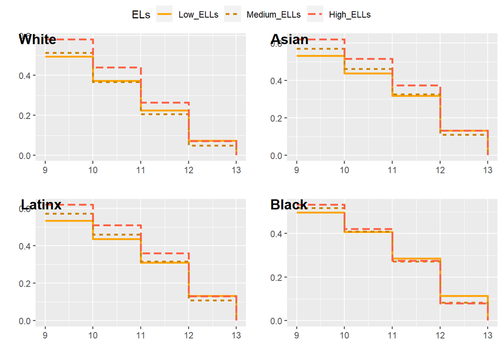

```r
fig3
```

## Effects of ELL composition by profiles of students

## Dropout

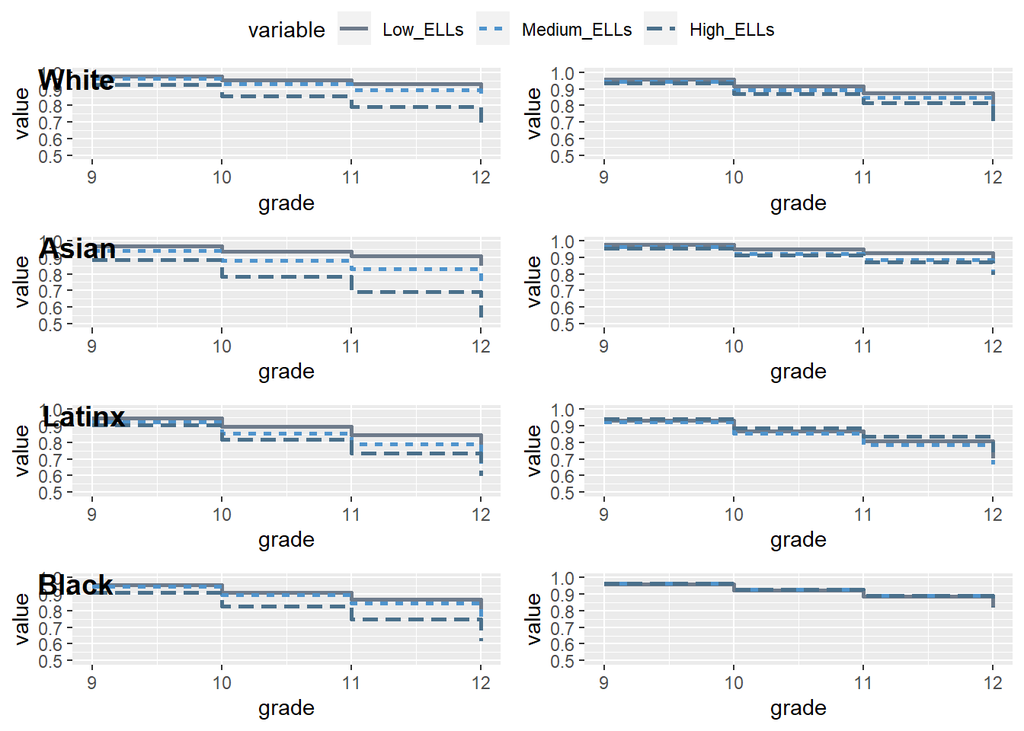

```r
fig4
```